# K-Means Clustering of Bacteria

Cassandra Sperow

2023-10-9

# K-means

- Question for Dr. Barouti: If K-means is giving random results every time I run it, is it a good method to use since this seems unstable? (The sizes of the 239 clusters change each time.)

Goal: Find groups (i.e., essentially networks) of bacteria that tend to be found together. Use these to see if bacteria features can be paired down from the already reduced 5,890 ASV `rev_bacteria_prop_df` .

- Use the results from the PCA that about 239 principal components explain at least 80 % of the bacteria data.

### Read in `rev_bacteria_prop_df` data

- This is the revised bacteria data that is proportion-based by row sums. See `Bacteria_Proportions.Rmd` for details.

```r
# read in the new proportion-based bacteria data
read_csv("../output/rev_bacteria_prop_df.csv") -> rev_bacteria_prop_df
head(rev_bacteria_prop_df)
```

```
## # A tibble: 6 × 5,890
##   sample_id ASV0001 ASV0002 ASV0003 ASV0004 ASV0005 ASV0006 ASV0007 ASV0008
##   <chr>       <dbl>   <dbl>   <dbl>   <dbl>   <dbl>   <dbl>   <dbl>   <dbl>
## 1 SMAQ-R1-1  0.188        0 0       0.00319  0.0870  0.0618  0.0518       0
## 2 SMAQ-R1-2  0.0522       0 0       0.0206   0.196   0.132   0.0170       0
## 3 SMAQ-R1-3  0.0292       0 0.00126 0.00883  0.246   0.158   0.0101       0
## 4 SMAQ-R1-4  0.213        0 0       0.00487  0.121   0.0743  0.0678       0
## 5 SMAQ-R1-5  0.123        0 0       0.0153   0.235   0.116   0.0361       0
## 6 SMAQ-R1-6  0.415        0 0       0.00686  0.0305  0.0167  0.118        0
## # ℹ 5,881 more variables: ASV0009 <dbl>, ASV0010 <dbl>, ASV0011 <dbl>,
## #   ASV0012 <dbl>, ASV0013 <dbl>, ASV0014 <dbl>, ASV0015 <dbl>, ASV0016 <dbl>,
## #   ASV0017 <dbl>, ASV0018 <dbl>, ASV0019 <dbl>, ASV0020 <dbl>, ASV0022 <dbl>,
## #   ASV0023 <dbl>, ASV0024 <dbl>, ASV0025 <dbl>, ASV0027 <dbl>, ASV0030 <dbl>,
## #   ASV0031 <dbl>, ASV0032 <dbl>, ASV0033 <dbl>, ASV0034 <dbl>, ASV0035 <dbl>,
## #   ASV0036 <dbl>, ASV0037 <dbl>, ASV0039 <dbl>, ASV0040 <dbl>, ASV0041 <dbl>,
## #   ASV0042 <dbl>, ASV0043 <dbl>, ASV0044 <dbl>, ASV0046 <dbl>, …
```

## Test stability of K-means on subset of data, default K-means algorithm

```r
set.seed(92)
random_columns = sample(1:5890, size=2000)

rev_bacteria_prop_df %>%
  # random sample of rows
  slice_sample(n=400) %>%
  # random sample of columns indexed with random generator above
  select(all_of(random_columns)) -> random_subset

random_subset %>% head()
```

```
## # A tibble: 6 × 2,000
##   ASV5850 ASV11660 ASV4409 ASV1204 ASV6560 ASV8445 ASV2426 ASV4887 ASV2222
##     <dbl>    <dbl>   <dbl>   <dbl>   <dbl>   <dbl>   <dbl>   <dbl>   <dbl>
## 1       0        0       0       0       0       0       0       0       0
## 2       0        0       0       0       0       0       0       0       0
## 3       0        0       0       0       0       0       0       0       0
## 4       0        0       0       0       0       0       0       0       0
## 5       0        0       0       0       0       0       0       0       0
## 6       0        0       0       0       0       0       0       0       0
## # ℹ 1,991 more variables: ASV6299 <dbl>, ASV3029 <dbl>, ASV5725 <dbl>,
## #   ASV9660 <dbl>, ASV0629 <dbl>, ASV1073 <dbl>, ASV7636 <dbl>, ASV1248 <dbl>,
## #   ASV0013 <dbl>, ASV3273 <dbl>, ASV7150 <dbl>, ASV2772 <dbl>, ASV6502 <dbl>,
## #   ASV5063 <dbl>, ASV13323 <dbl>, ASV6273 <dbl>, ASV0431 <dbl>, ASV1683 <dbl>,
## #   ASV22545 <dbl>, ASV2862 <dbl>, ASV4145 <dbl>, ASV6183 <dbl>, ASV1873 <dbl>,
## #   ASV2510 <dbl>, ASV2181 <dbl>, ASV2605 <dbl>, ASV0402 <dbl>, ASV6721 <dbl>,
## #   ASV3454 <dbl>, ASV3095 <dbl>, ASV4878 <dbl>, ASV2418 <dbl>, …
```

```r
dim(random_subset) # 400 by 2000
```

```
## [1]  400 2000
```

- Random subset keeps giving me columns that have NaN values when scaled in K-means, so need to take out those columns for a good subset while still having a lot more columns than observations like original.

```r
# exploring which columns are creating NaN values
random_subset %>%
  scale() %>% as.data.frame() %>%
  # map over all columns to see which ones have NaN values
  map(., ~sum(is.nan(.))) %>% as.data.frame() %>%
  # transpose the list of values from map into vertical df
  t() %>%  as.data.frame() %>%
  # view which ones and how many have NO NaN values
  filter(V1 == 0)
```

```
##          V1
## ASV5850   0
## ASV1204   0
## ASV6560   0
## ASV8445   0
## ASV2426   0
## ASV4887   0
## ASV2222   0
## ASV6299   0
## ASV3029   0
## ASV5725   0
## ASV9660   0
## ASV0629   0
## ASV1073   0
## ASV7636   0
## ASV1248   0
## ASV0013   0
## ASV3273   0
## ASV7150   0
## ASV2772   0
## ASV6502   0
## ASV5063   0
## ASV13323  0
## ASV6273   0
## ASV0431   0
## ASV1683   0
## ASV22545  0
## ASV2862   0
## ASV6183   0
## ASV1873   0
## ASV2510   0
## ASV2181   0
## ASV2605   0
## ASV0402   0
## ASV6721   0
## ASV3454   0
## ASV3095   0
## ASV4878   0
## ASV2418   0
## ASV2869   0
```

[output cut: 1886 more lines]

```
## ASV11405  0
## ASV0328   0
## ASV1906   0
## ASV2919   0
## ASV5453   0
## ASV0686   0
## ASV1001   0
## ASV3846   0
## ASV3001   0
## ASV3329   0
## ASV5634   0
## ASV2113   0
## ASV14797  0
## ASV16599  0
## ASV3656   0
```

# Solution of iteratively removing columns with any NaN values before K-means

- found via this link
- https://stackoverflow.com/questions/12454487/remove-columns-from-dataframe-where-some-of-values-are-na

```r
# create object to pass into solution for removing columns that have any sort of NaN value
scale(random_subset) -> sc_random


sc_random[, colSums(is.nan(sc_random)) == 0] %>%
  as.data.frame() -> sc_random_df
```

```r
# inspect new df
head(sc_random_df)
```

```
##   ASV5850    ASV1204    ASV6560     ASV8445     ASV2426     ASV4887 ASV2222
## 1   -0.05 -0.1307566 -0.1103101 -0.06719997 -0.08915151 -0.07492545   -0.05
## 2   -0.05 -0.1307566 -0.1103101 -0.06719997 -0.08915151 -0.07492545   -0.05
## 3   -0.05 -0.1307566 -0.1103101 -0.06719997 -0.08915151 -0.07492545   -0.05
## 4   -0.05 -0.1307566 -0.1103101 -0.06719997 -0.08915151 -0.07492545   -0.05
## 5   -0.05 -0.1307566 -0.1103101 -0.06719997 -0.08915151 -0.07492545   -0.05
## 6   -0.05 -0.1307566 -0.1103101 -0.06719997 -0.08915151 -0.07492545   -0.05
##       ASV6299     ASV3029     ASV5725     ASV9660     ASV0629    ASV1073
## 1 -0.09404355 -0.07365101 -0.07866646 -0.07251903 -0.08576481 -0.1479222
## 2 -0.09404355 -0.07365101 -0.07866646 -0.07251903 -0.08576481 -0.1479222
## 3 -0.09404355 -0.07365101 -0.07866646 -0.07251903 -0.08576481 -0.1479222
## 4 -0.09404355 -0.07365101 -0.07866646 -0.07251903 -0.08576481 10.2686351
## 5 -0.09404355 -0.07365101 -0.07866646 -0.07251903 -0.08576481 -0.1479222
## 6 -0.09404355 -0.07365101 -0.07866646 -0.07251903 -0.08576481 -0.1479222
##       ASV7636     ASV1248    ASV0013     ASV3273     ASV7150     ASV2772
```

[output cut: 2092 more lines]

## Run K-Means on Random Subset with no NAN values

```r
stats::kmeans(sc_random_df,
              centers = 239,
              #nstart = 10 # takes long time to run
              ) -> kmeans_out
```

```r
summary(kmeans_out)
```

```
##              Length Class  Mode
## cluster         400 -none- numeric
## centers      463660 -none- numeric
## totss             1 -none- numeric
## withinss        239 -none- numeric
## tot.withinss      1 -none- numeric
## betweenss         1 -none- numeric
## size            239 -none- numeric
## iter              1 -none- numeric
## ifault            1 -none- numeric
```

#### The cluster sizes keep changing each time I run K-means and setting the seed would be an artifical, unrepresentative way to get it to produce stable output.

```r
kmeans_out$size
```

```
##   [1]  1 23  1  1  1  1  1  1  2  1  1  1  1  1 94  1  1  1  1  2  1  1  1  1  2
##  [26]  1  1  1  1  3  1  1  1  2  1  1  1  1  1  1  2  1  1  1  1  1  1  1  1  1
##  [51]  1  1  1  1  1  1  1 17  1  1  1  1  1  1  1  1  1  1  1  1  1  2  1  1  2
##  [76]  1  1  1  1  1  1  1  1  8  1  1  2  1  2  1  1  1  1  1  1  1  1  1  1  1
## [101]  1  1  1  1  1  1  1  1  1  1  1  1  2  1  1  1  1  1  1  1  1  1  1  1  1
## [126]  1  1  1  2  1  3  1  1  1  1  1  1  1  1  1  1  1  1  1  1  1  1  1  1  1
## [151]  1  1  1  1  1  1  1  1  1  1  1  1  1  1  1  1  1  1  1  3  1  1  1  1  1
## [176]  1  1  1  1  1  1  1  1  1  1  1  1  1  1  1  1  2  1  1  1  1  1  1  1  1
## [201]  1  1  1  1  1  1  1  1  1  1  1  1  1  1  1  1  4  1  1  3  1  1  1  1  1
## [226]  1  1  1  1  1  1  1  1  1  1  1  1  1  1
```

## PAM

Documentation: https://www.rdocumentation.org/packages/cluster/versions/2.1.4/topics/pam

- Review format of data frame:

```r
# review format of data
# no id column
# all numeric
# scaled
# reduced size of 400 x 1940
head(sc_random_df)
```

```
##   ASV5850    ASV1204    ASV6560     ASV8445     ASV2426     ASV4887 ASV2222
## 1   -0.05 -0.1307566 -0.1103101 -0.06719997 -0.08915151 -0.07492545   -0.05
## 2   -0.05 -0.1307566 -0.1103101 -0.06719997 -0.08915151 -0.07492545   -0.05
## 3   -0.05 -0.1307566 -0.1103101 -0.06719997 -0.08915151 -0.07492545   -0.05
## 4   -0.05 -0.1307566 -0.1103101 -0.06719997 -0.08915151 -0.07492545   -0.05
## 5   -0.05 -0.1307566 -0.1103101 -0.06719997 -0.08915151 -0.07492545   -0.05
## 6   -0.05 -0.1307566 -0.1103101 -0.06719997 -0.08915151 -0.07492545   -0.05
##       ASV6299     ASV3029     ASV5725     ASV9660     ASV0629    ASV1073
## 1 -0.09404355 -0.07365101 -0.07866646 -0.07251903 -0.08576481 -0.1479222
## 2 -0.09404355 -0.07365101 -0.07866646 -0.07251903 -0.08576481 -0.1479222
## 3 -0.09404355 -0.07365101 -0.07866646 -0.07251903 -0.08576481 -0.1479222
## 4 -0.09404355 -0.07365101 -0.07866646 -0.07251903 -0.08576481 10.2686351
## 5 -0.09404355 -0.07365101 -0.07866646 -0.07251903 -0.08576481 -0.1479222
## 6 -0.09404355 -0.07365101 -0.07866646 -0.07251903 -0.08576481 -0.1479222
##       ASV7636     ASV1248    ASV0013     ASV3273     ASV7150     ASV2772
```

[output cut: 2092 more lines]

```r
library(cluster)
pam(x=sc_random_df, # df where each row is coral sample obs
    k = 239, # 239 explains at least 80 % from PCA
    diss = F, #F = x is df of observationsnot dissim matrix
    metric = "euclidean", # not manhattan
    # may ocnsider changing to L1 norm if PAM with euclidean doesn't work out
    #medoids = if(is.numeric(nstart)) "random",
    #nstart = if(variant == "faster") 1 else NA,
    stand = TRUE, # F = x is not standardized
   # cluster.only = T,
    do.swap = TRUE, # T = yes, do swap phase of algorithm
    # keep.diss = !diss && !cluster.only && n < 100,
    # keep.data = !diss && !cluster.only,
    variant = "original" ,# c("original", "o_1", "o_2", "f_3", "f_4", "f_5", "faster"),
   # pamonce = FALSE,
    trace.lev = 0) -> pam_out
```

```r
pam_out %>% glimpse()
```

```
## List of 10
##  $ medoids   : num [1:239, 1:1940] -0.05 -0.05 -0.05 -0.05 -0.05 -0.05 -0.05 -0.05 -0.05 -0.05 ...
##   ..- attr(*, "dimnames")=List of 2
##   .. ..$ : NULL
##   .. ..$ : chr [1:1940] "ASV5850" "ASV1204" "ASV6560" "ASV8445" ...
##  $ id.med    : int [1:239] 1 4 5 6 7 9 10 11 13 14 ...
##  $ clustering: int [1:400] 1 1 1 2 3 4 5 1 6 7 ...
##  $ objective : Named num [1:2] 45.8 45.8
##   ..- attr(*, "names")= chr [1:2] "build" "swap"
##  $ isolation : Factor w/ 3 levels "no","L","L*": 1 1 1 1 1 1 1 1 1 1 ...
##   ..- attr(*, "names")= chr [1:239] "1" "2" "3" "4" ...
##  $ clusinfo  : num [1:239, 1:5] 162 1 1 1 1 1 1 1 1 1 ...
##   ..- attr(*, "dimnames")=List of 2
##   .. ..$ : NULL
##   .. ..$ : chr [1:5] "size" "max_diss" "av_diss" "diameter" ...
##  $ silinfo   :List of 3
##   ..$ widths         : num [1:400, 1:3] 1 1 1 1 1 1 1 1 1 1 ...
##   .. ..- attr(*, "dimnames")=List of 2
##   ..$ clus.avg.widths: num [1:239] 0.29 0 0 0 0 ...
##   ..$ avg.width      : num 0.118
##  $ diss      : NULL
##  $ call      : language pam(x = sc_random_df, k = 239, diss = F, metric = "euclidean", stand = TRUE,      do.swap = TRUE, variant = "orig| __truncated__
##  $ data      : num [1:400, 1:1940] -0.501 -0.501 -0.501 -0.501 -0.501 ...
##   ..- attr(*, "scaled:center")= num [1:1940] 2.38e-18 1.05e-17 -1.04e-17 -2.91e-18 -1.17e-17 ...
##   ..- attr(*, "scaled:scale")= num [1:1940] 0.0997 0.2511 0.2179 0.1337 0.1761 ...
##   ..- attr(*, "dimnames")=List of 2
##   .. ..$ : NULL
##   .. ..$ : chr [1:1940] "ASV5850" "ASV1204" "ASV6560" "ASV8445" ...
##  - attr(*, "class")= chr [1:2] "pam" "partition"
```

```r
summary(pam_out) -> pam_summary
```

```r
pam_out$clusinfo
```

```
##        size max_diss  av_diss diameter separation
##   [1,]  162 206.5328 113.1169 291.6214   184.0770
##   [2,]    1   0.0000   0.0000   0.0000   383.9806
##   [3,]    1   0.0000   0.0000   0.0000   280.0121
##   [4,]    1   0.0000   0.0000   0.0000   250.7425
##   [5,]    1   0.0000   0.0000   0.0000   261.6309
##   [6,]    1   0.0000   0.0000   0.0000   212.7918
##   [7,]    1   0.0000   0.0000   0.0000   205.3820
##   [8,]    1   0.0000   0.0000   0.0000   286.4241
##   [9,]    1   0.0000   0.0000   0.0000   268.0069
##  [10,]    1   0.0000   0.0000   0.0000   215.7172
##  [11,]    1   0.0000   0.0000   0.0000   399.8775
##  [12,]    1   0.0000   0.0000   0.0000   275.8795
##  [13,]    1   0.0000   0.0000   0.0000   449.9933
##  [14,]    1   0.0000   0.0000   0.0000   293.4356
```

[output cut: 225 more lines]

- Is the PAM algorithm giving stable results each time it’s run?

```r
# re-run to compaure cluster sizes, etc.
pam(x=sc_random_df, # df where each row is coral sample obs
    k = 239, # 239 explains at least 80 % from PCA
    diss = F, #F = x is df of observationsnot dissim matrix
    metric = "euclidean", # not manhattan
    # may ocnsider changing to L1 norm if PAM with euclidean doesn't work out
    #medoids = if(is.numeric(nstart)) "random",
    #nstart = if(variant == "faster") 1 else NA,
    stand = TRUE, # F = x is not standardized
   # cluster.only = T,
    do.swap = TRUE, # T = yes, do swap phase of algorithm
    # keep.diss = !diss && !cluster.only && n < 100,
    # keep.data = !diss && !cluster.only,
    variant = "original" ,# c("original", "o_1", "o_2", "f_3", "f_4", "f_5", "faster"),
   # pamonce = FALSE,
    trace.lev = 0) -> pam_out2
```

```r
# are the clustering results the same?
# if the two cluster info results objects have any mismatch FLASE values, then it will add them here
sum(pam_out2$clusinfo != pam_out$clusinfo)
```

```
## [1] 0
```

```r
pam_out$silinfo$avg.width
```

```
## [1] 0.1176008
```

### Plot of PAM Results

```r
library(factoextra)
```

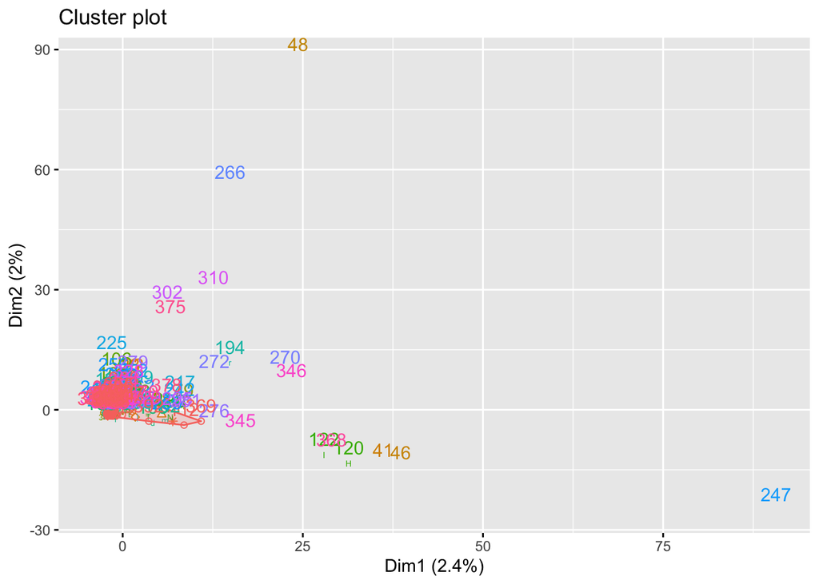

```r
fviz_cluster(pam_out,
             legend = "none"
             )
```

- Visualize Silhouette Info

```
##     cluster size ave.sil.width
## 1         1  162          0.29
## 2         2    1          0.00
## 3         3    1          0.00
## 4         4    1          0.00
## 5         5    1          0.00
## 6         6    1          0.00
## 7         7    1          0.00
## 8         8    1          0.00
## 9         9    1          0.00
## 10       10    1          0.00
## 11       11    1          0.00
## 12       12    1          0.00
## 13       13    1          0.00
## 14       14    1          0.00
```

[output cut: 225 more lines]

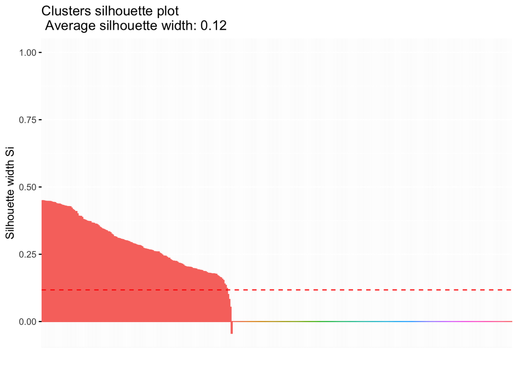

```r
fviz_silhouette(pam_out,
                legend = "none")
```

- From the documentation for fviz_silhouette() on pg 64 at link to PDF on CRAN: https://cran.r-project.org/web/packages/factoextra/factoextra.pdf

– “Observations with a large silhouhette Si (almost 1) are very well clustered. – A small Si (around 0) means that the observation lies between two clusters. – Observations with a negative Si are probably placed in the wrong cluster.”

**Interpretation based on this: None of the Si values are close to 1; they are closer to 0. This clustering is most likely not clustering well.**

**This was assuming that the PCA of 239 PCs was the best number of clusters to look for when clustering.**

## NBClust - I do not think this is right

- Using this source to attempt to find optimal number of clusters: https://www.datanovia.com/en/lessons/determining-the-optimal-number-of-clusters-3-must-know-methods/

```r
fviz_nbclust(sc_random_df,
             FUNcluster = pam,
             method = "silhouette") -> nbclust_out
```

### Plot NBClust Results

- The highest average silhouette width is indicated with the dashed line

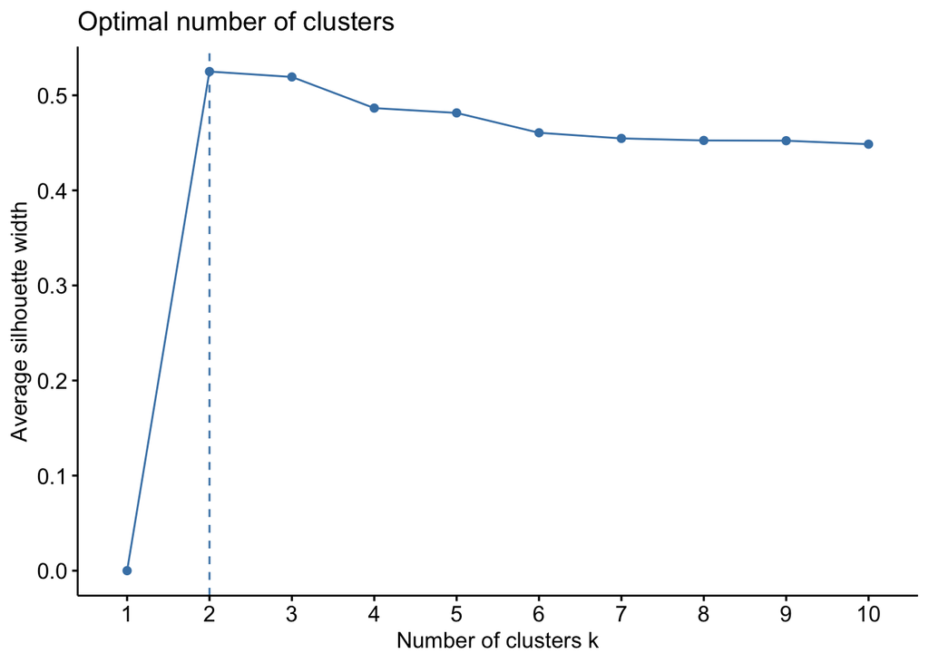

```r
nbclust_out
```

## NBClust with Elbow Method

```r
fviz_nbclust(sc_random_df,
             FUNcluster = pam,
             method = "wss") -> nbclust_out_elbow
```

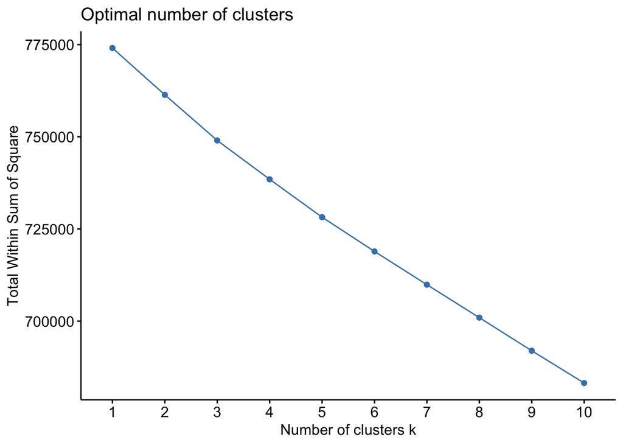

```r
nbclust_out_elbow
```

### Gap Statistic Method

- Takes a very long time to run
- Did not have available time and might need to try again later

```r
# fviz_nbclust(sc_random_df,
#              FUNcluster = pam,
#              method = "gap_stat") -> nbclust_out_gap
```